# Assignment 2: Feature Engineering, Statistical Analysis and Machine Learning

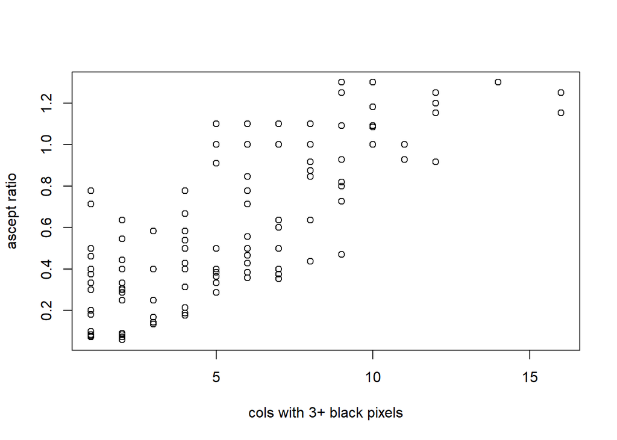

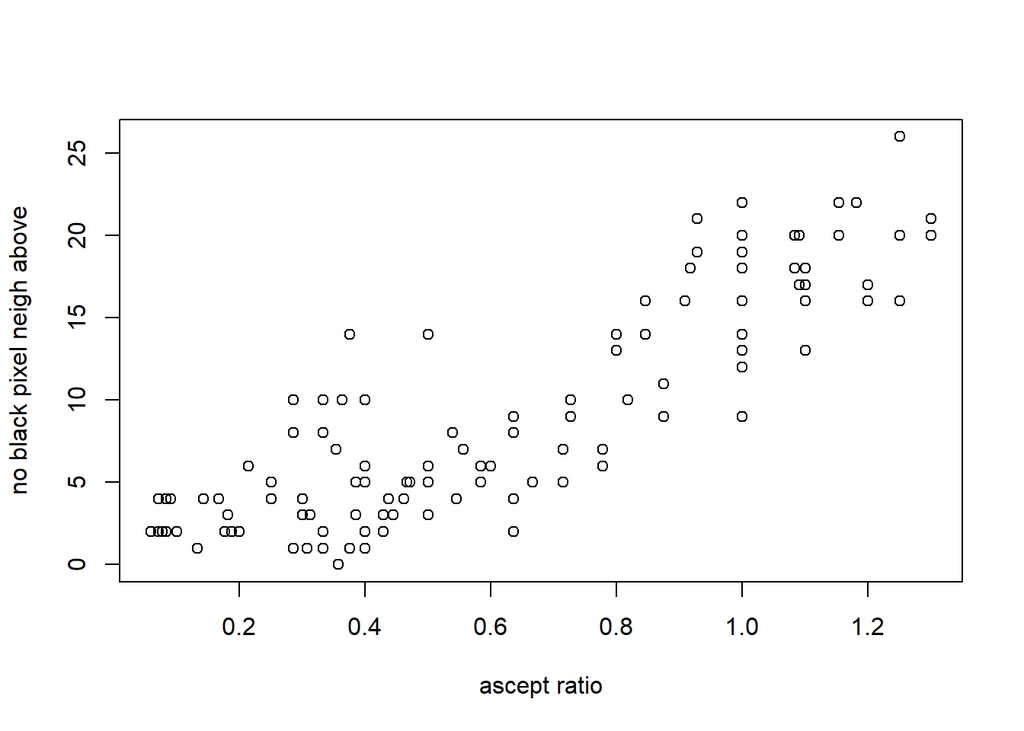

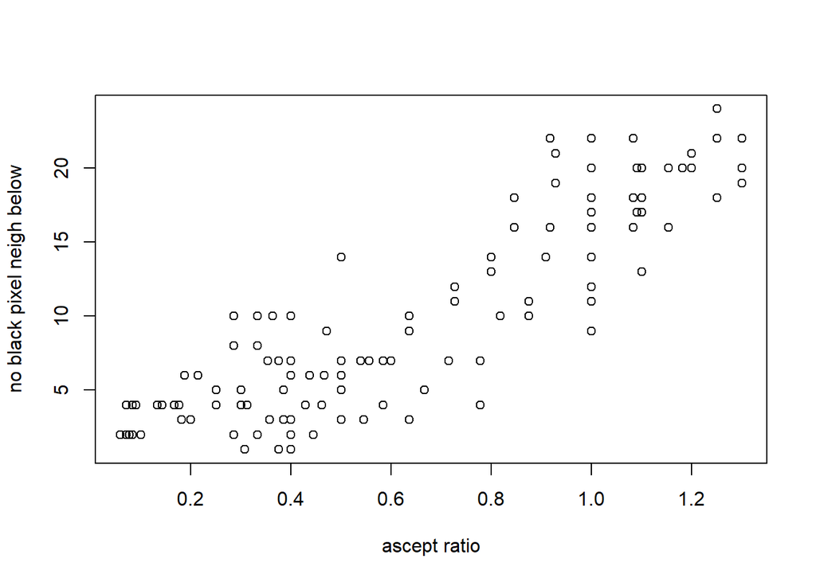

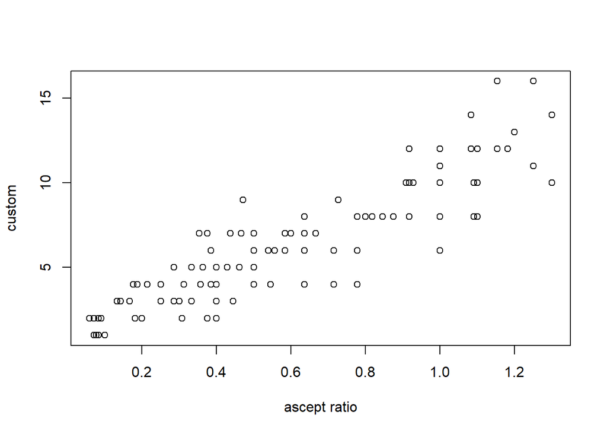

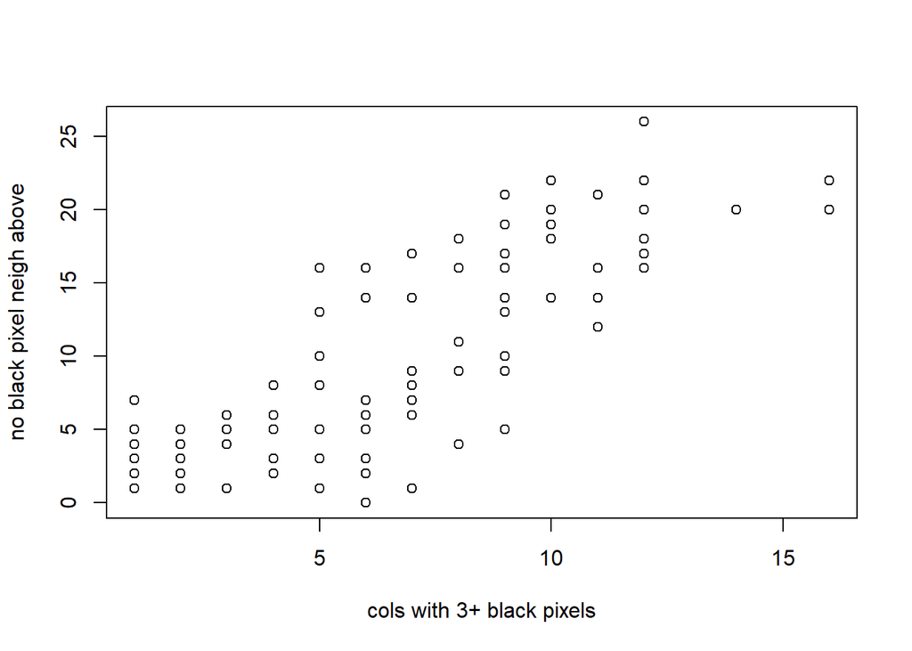

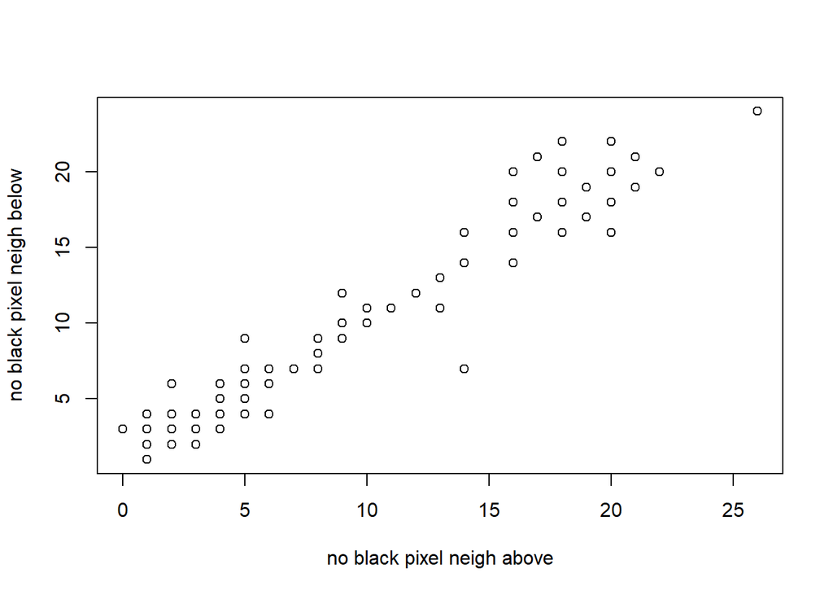

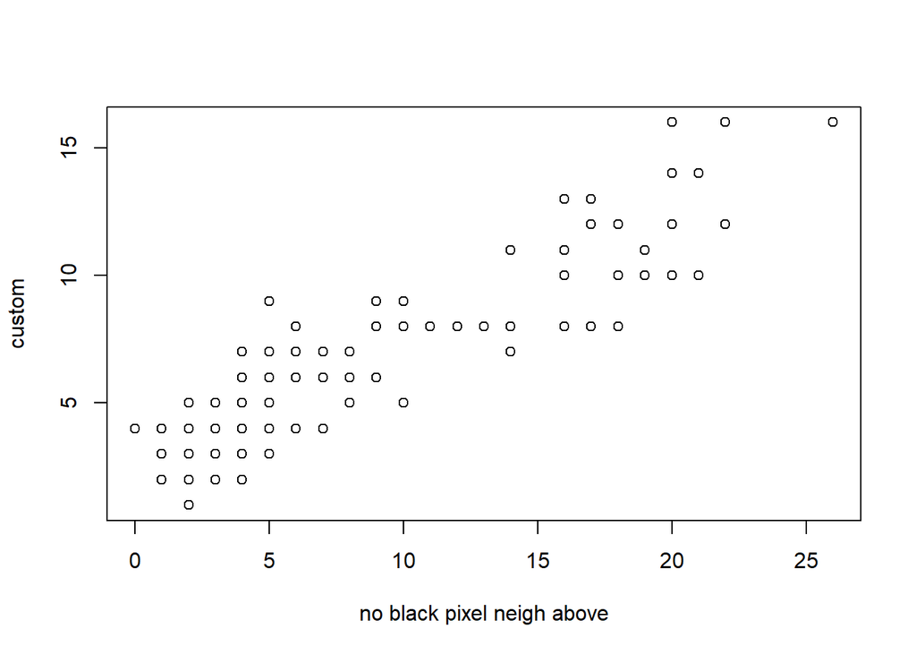

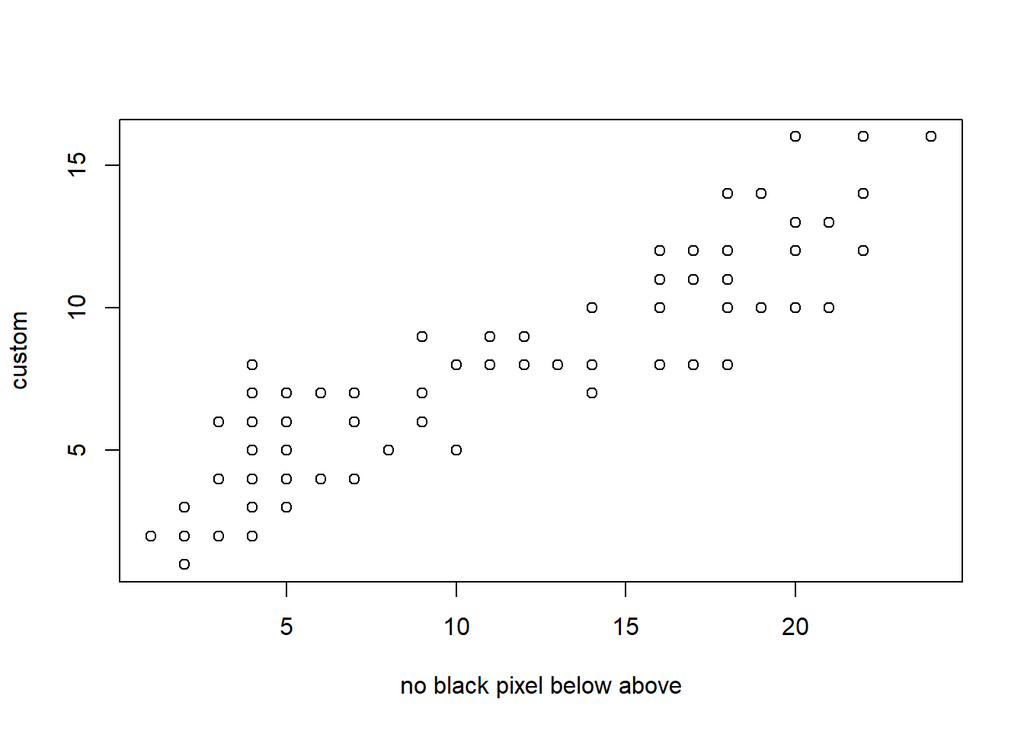

[2 more figures not shown]

For the 4th scatter plot, between widest black pixel row and cols with 3+ black pixel, it is clear by just looking at the scatter plot distrubution there is a degree of linear assosciation between the two, this is the case as the wider the row the more like there is to be more rows and cols like that, e.g. over 3+ black pixels hence giving a lot of 3+ black pixel cols, the graph clearly shows this

In terms of the aspect ratio scatter plots, it has a lot of features which it has a high degree of linear association with, these are cols with 3+ which has 0.79054621 cor value, no neigh above 0.8742152 cor value , no neigh below cor value 0.87366851 and widest row with black pixel 0.90665137 cor value. These plots are shown above and expected out of all them row with most black pixels and aspect ratio has the most significant distributions to show a degree of linear association, this is expected as because it uses the leftmost and rightmost black pixel and using the widest row therefore, this row that the custom feature is finding, therefore there is a significant association between the two.

The 10th scatter plot, is the highest degree of linear association between all the features, and looking at the scatter graph this is the case, as the distribution is nearly a perfect diagonal line and certainly the most perfect distribution we see out of these scatter plots as expected from the cor value. This relationship is so significant, because if a black pixel does not have above it, it could mean there is another black pixel with the same pixel space that does have a below neighbour.

For the second last feature, the left and right no black pixel has a cor value of 0.859115751. The significant degree of linear association is clear in the scatter plot, with the distrubution pattern showing that there is a relationship to the two, and it is simple why there. If a black pixel does not have a left neighbours another black pixel near it will not have a right neighbours, and vice versa leading to this relationship

For the last feature the cor is 0.742534541 between rows with 1 black pixel and no neigh horiz, one of the smallest value for the significant correlations and this is clear on the scatter plot as the distribution does not show one of relationship between the two, although there is a high cor value for the two, they may not have a high degree of linear association between the two features.

To conclude I believe I have highlighted the most significant relationships and provided scatter plots which I have used to describe why there may be a degree of linear association between the two features.

# Section 4

## Section 4.1

```
##  [1] ".GlobalEnv"         "package:MASS"       "package:psych"
##  [4] "package:ggplot2"    "package:data.table" "package:knitr"
##  [7] "package:rstudioapi" "package:raster"     "package:sp"
## [10] "package:stats"      "package:graphics"   "package:grDevices"
## [13] "package:utils"      "package:datasets"   "package:methods"
## [16] "Autoloads"          "package:base"
```

```
## [1] "C:/Users/eunan/Documents/CSC2062 Assignment 2"
```

```
##
## Call:
## lm(formula = aspect_ratio ~ nr_pix + rows_with_1 + cols_with_1 +
##     rows_with_3p + cols_with_3p + neigh_1 + no_neigh_above +
##     no_neigh_below + no_neigh_left + no_neigh_right + no_neigh_horiz +
##     no_neigh_vert + connected_areas + eyes + custom, data = csvF)
##
## Residuals:
##       Min        1Q    Median        3Q       Max
## -0.279393 -0.065511 -0.008668  0.068580  0.300786
##
## Coefficients:
##                  Estimate Std. Error t value Pr(>|t|)
## (Intercept)      0.341097   0.055373   6.160 9.33e-09 ***
## nr_pix          -0.002922   0.001030  -2.838 0.005301 **
## rows_with_1     -0.018600   0.005234  -3.554 0.000539 ***
## cols_with_1      0.027333   0.008551   3.196 0.001766 **
## rows_with_3p     0.003366   0.003930   0.857 0.393349
## cols_with_3p     0.020738   0.008520   2.434 0.016351 *
## neigh_1          0.013820   0.012934   1.069 0.287368
## no_neigh_above   0.013544   0.006918   1.958 0.052499 .
## no_neigh_below   0.007007   0.006783   1.033 0.303579
## no_neigh_left   -0.001529   0.005697  -0.268 0.788869
## no_neigh_right  -0.014832   0.006363  -2.331 0.021360 *
## no_neigh_horiz   0.011913   0.003546   3.360 0.001037 **
## no_neigh_vert   -0.002262   0.003027  -0.747 0.456318
## connected_areas -0.042928   0.016035  -2.677 0.008430 **
## eyes            -0.026158   0.033712  -0.776 0.439277
## custom           0.044436   0.008250   5.386 3.47e-07 ***
## ---
## Signif. codes:  0 '***' 0.001 '**' 0.01 '*' 0.05 '.' 0.1 ' ' 1
##
## Residual standard error: 0.1075 on 124 degrees of freedom
## Multiple R-squared:  0.9198, Adjusted R-squared:  0.9101
## F-statistic: 94.81 on 15 and 124 DF,  p-value: < 2.2e-16
##
## Start:  AIC=-609.55
## aspect_ratio ~ nr_pix + rows_with_1 + cols_with_1 + rows_with_3p +
##     cols_with_3p + neigh_1 + no_neigh_above + no_neigh_below +
##     no_neigh_left + no_neigh_right + no_neigh_horiz + no_neigh_vert +
```

[output cut: 151 more lines]

```
## nr_pix          -0.0023211  0.0008321  -2.789 0.006075 **
## rows_with_1     -0.0155955  0.0046432  -3.359 0.001028 **
## cols_with_1      0.0290180  0.0073415   3.953 0.000126 ***
## cols_with_3p     0.0177960  0.0074680   2.383 0.018621 *
## no_neigh_above   0.0190536  0.0046693   4.081 7.79e-05 ***
## no_neigh_right  -0.0144056  0.0039399  -3.656 0.000370 ***
## no_neigh_horiz   0.0099421  0.0029510   3.369 0.000993 ***
## connected_areas -0.0375398  0.0149319  -2.514 0.013155 *
## custom           0.0470077  0.0079086   5.944 2.41e-08 ***
## ---
## Signif. codes:  0 '***' 0.001 '**' 0.01 '*' 0.05 '.' 0.1 ' ' 1
##
## Residual standard error: 0.1068 on 130 degrees of freedom
## Multiple R-squared:  0.917,  Adjusted R-squared:  0.9113
## F-statistic: 159.6 on 9 and 130 DF,  p-value: < 2.2e-16
```

## Section 4.2

```
##   [1] 0 0 0 0 0 0 0 0 0 0 0 0 0 0 0 0 0 0 0 0 0 0 0 0 0 0 0 0 0 0 0 0 0 0 0 0 0
##  [38] 0 0 0 0 0 0 0 0 0 0 0 0 0 0 0 0 0 0 0 0 0 0 0 0 0 0 0 0 0 0 0 0 0 0 0 0 0
##  [75] 0 0 0 0 0 0 0 0 0 0 0 0 0 0 0 0 0 0 0 0 0 0 0 0 0 0 0 0 0 0 0 0 0 0 0 0 0
## [112] 0 0 0 0 0 0 0 0 0 0 0 0 0 0 0 0 0 0 0 0 0 0 0 0 0 0 0 0 0
```

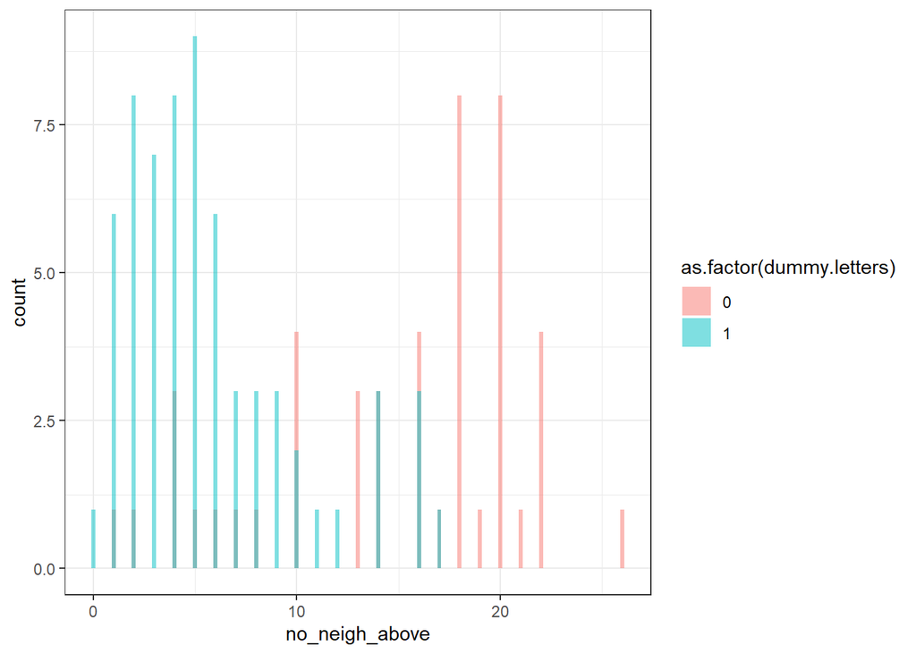

```
##
## Call:
## glm(formula = dummy.letters ~ no_neigh_above, family = "binomial",
##     data = trainingdata)
##
## Deviance Residuals:
##     Min       1Q   Median       3Q      Max
## -2.3525  -0.5521   0.4094   0.5949   1.8619
##
## Coefficients:
##                Estimate Std. Error z value Pr(>|z|)
## (Intercept)     2.96740    0.51887   5.719 1.07e-08 ***
## no_neigh_above -0.26508    0.04555  -5.819 5.91e-09 ***
## ---
## Signif. codes:  0 '***' 0.001 '**' 0.01 '*' 0.05 '.' 0.1 ' ' 1
##
## (Dispersion parameter for binomial family taken to be 1)
##
##     Null deviance: 152.360  on 111  degrees of freedom
## Residual deviance:  97.038  on 110  degrees of freedom
## AIC: 101.04
##
## Number of Fisher Scoring iterations: 4
##
##         1         2         3
## 0.8378073 0.5784977 0.0883317
```

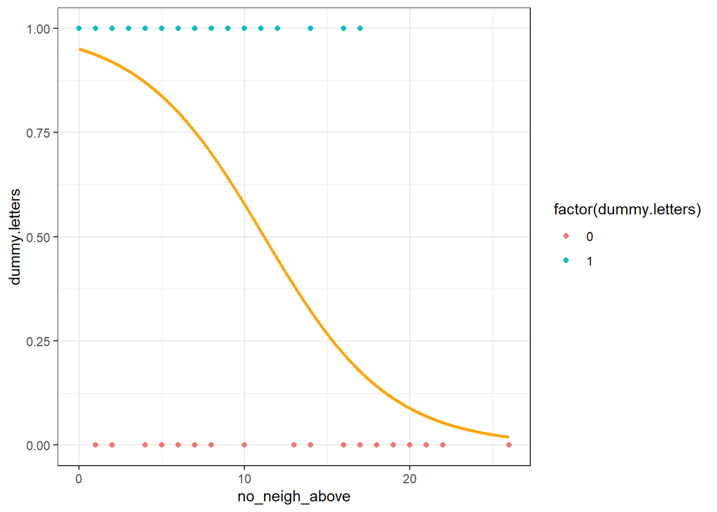

```
## [1] "Prop correct for training data"
## [1] 0.8125
## [1] "Prop incorrect for training data"
## [1] 0.1875
## [1] "Prop correct for test data"
## [1] 0.7857143
## [1] "Prop incorrect for test data"
## [1] 0.2142857
```

The results are shown on the graph above as well as the accuracy of the model. The plot shows that the lower the no_neigh_above the more chance it is a letter. Based on the predictions I did of 5 10 20, which came out as 0.83…, 0.57… and 0.0883… respectfully, this is proven to be the case on the plot. It is 81.25% accurate for training data and 78.57% for test data, It is expected that training data is higher % as it was used to fit the model.

## Section 4.3 and 4.4

```
##                   Split1 Split2 Split3
## Letters           0.3875  0.375 0.5375
## Faces             0.6250  1.000 0.5750
## Exclamation Marks 0.7000  0.000 0.1500
## [1] "Naive bayes classifer for all 1s in letters"
## [1] 0.0446317
## [1] "Naive bayes classifer for all 0s in letters"
## [1] 0.1011719
## [1] "Naive bayes classifer for all 1s in faces"
## [1] 0.1026786
## [1] "Naive bayes classifer for all 0s in faces"
## [1] 0
## [1] "Naive bayes classifer for all 1s in xclaim"
## [1] 0
## [1] "Naive bayes classifer for all 0s in xclaim"
## [1] 0.03642857
```